# PHYS 210 Day 15 - Oct 27, 2025

Agenda:

1. Announcements
2. Reading recap, polling questions and Q&A

**Please get your iclicker up and running**

## Announcements (Project 02) - Observations from early grading efforts

1. The period (T) from Homework 11, Part 2 is meant to help establish reasonable order of magnitude times and initial speeds for running your simulation, but these will no longer be the actual period lengths in your simulation
2. Although this is an empirical investigation, make sure to tie your results back to your physics understanding and intuition
3. Do not treat the first heat map you create as the end of your investigation...it should provide a mechanism to notice interesting features and fine-tune your investigations

## Reading recap, polling questions and Q&A

**Random number libraries**

- `random` module: `random.uniform(a, b)`
- `numpy.random`: `np.random.uniform(a, b, size)`
- `secrets` module: generating cryptographically secure random numbers and strings
- `scipy.stats`: a huge number of specialized statistical distributions

**Q:** Can you go over the sin(x) Monte Carlo solution?

Let's first jump to an example similar to the estimation of pi

**Monte-Carlo integration - volume of a sphere**

```python
import numpy as np
import matplotlib.pyplot as plt
from mpl_toolkits.mplot3d import Axes3D
r = np.random.uniform(-1,1,(5,3))
r
```

```
array([[ 0.05184121,  0.09432615,  0.35143253],
       [ 0.2360549 ,  0.1845536 ,  0.12377675],
       [-0.16191202, -0.48742387, -0.35862355],
       [ 0.09545535,  0.11615923,  0.94147556],
       [-0.59447718, -0.02967808, -0.88815123]])
```

**Polling Q1** If we are trying to calculate the volume of a sphere with `r=1`, how should we write our volume calculation expression?

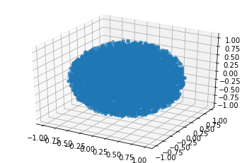

```python
r = np.random.uniform(-1,1,(10000,3))
rin = r[ r[:,0]**2 + r[:,1]**2 + r[:,2]**2 <= 1 ]

fig = plt.figure()
ax = fig.add_subplot(111, projection='3d')
ax.scatter(rin[:, 0], rin[:, 1], rin[:, 2])
plt.show()
```

**Polling Q1:** If we are trying to calculate the volume of a sphere with `r=1`, how should we write our volume calculation expression?

```python
r = np.random.uniform(-1,1,(10000,3))
rin = r[ r[:,0]**2 + r[:,1]**2 + r[:,2]**2 <= 1 ]

vol_A = 4/3 * np.pi * rin.size/r.size
vol_B = 8 * rin.size/r.size
vol_C = 2 * rin.size/r.size
vol_D = 1/8 * rin.size/r.size
vol_E = 1/2 * rin.size/r.size
```

```python
a = 8 # Update this
print(f"MC = {a*rin.size/r.size}, Volume = {4/3*np.pi:.3f}")
```

```
MC = 4.268, Volume = 4.189
```

**Monte-Carlo integration - definite integral of sin**

Here's what I got when I asked ChatGPT:

- "python monte carlo integral of sin from 0 to pi"

Monte Carlo integration is a technique that uses random sampling to approximate the value of a definite integral. Here's how you can use the Monte Carlo method to estimate the integral of sin(x) from 0 to π.

1. Generate random points (x, y) where x is between 0 and π and y is between 0 and 1.
2. Count the number of points that lie below the curve y = sin(x).
3. The ratio of the points below the curve to the total number of points, multiplied by the area of the bounding box (which is $\pi \times 1 = \pi$ in this case), will give an approximation of the integral.

Here's the Python code to perform the Monte Carlo integration for sin(x):

```
import numpy as np

def monte_carlo_integration_sin(n_samples=100000):
    # Generate random x values between 0 and pi
    x = np.random.uniform(0, np.pi, n_samples)

    # Generate random y values between 0 and 1
    y = np.random.uniform(0, 1, n_samples)

    # Check how many points lie below y = sin(x)
    below_curve = y < np.sin(x)

    # Compute the ratio of points below the curve to total points
    ratio = np.sum(below_curve) / n_samples

    # The area of the bounding box is pi
    area_box = np.pi

    # Return the approximate integral
    return ratio * area_box

# Estimate the integral
integral_estimate = monte_carlo_integration_sin()
print(f"Monte Carlo estimate of the integral: {integral_estimate}")

# The actual value of the integral of sin(x) from 0 to pi is 2
print(f"Actual value: 2")
```

The more samples you use, the closer the estimate will be to the actual value. However, convergence can be slow, so for very accurate results, you might need a large number of samples.

```python
import numpy as np
def monte_carlo_integration_sin(n_samples=100000):
    # Generate random x values between 0 and pi and y between 0 and 1
    x = np.random.uniform(0, np.pi, n_samples)
    y = np.random.uniform(0, 1, n_samples)

    # Check how many points lie below y = sin(x)
    below_curve = y < np.sin(x)

    # Compute the ratio of points below the curve to total points
    ratio = np.sum(below_curve) / n_samples

    # The area of the bounding box is pi
    area_box = np.pi # pi wide by 1 tall

    # Return the approximate integral
    return ratio * area_box

integral_estimate = monte_carlo_integration_sin()
print(f"Monte Carlo estimate of the integral: {integral_estimate}")
print(f"Actual value: 2")
```

```
Monte Carlo estimate of the integral: 1.9947542553968391
Actual value: 2
```

**Polling Q2:** Modifications to calculate the integral from $-\pi$ to $\pi$ instead of 0 to $\pi$?  
A) `x` goes from $-\pi$ to $\pi$  
B) `y` goes from $-1$ to $1$  
C) `below_curve` needs to become `0 < y < np.sin(x)`  
D) Same as C but also need `above_curve = np.sin(x) < y < 0` and then use (`above_curve - below_curve`)  
E) All of the above

```python
def monte_carlo_integration_sin(n_samples=100000):
    x = np.random.uniform(0, np.pi, n_samples)
    y = np.random.uniform(0, 1, n_samples)
    below_curve = y < np.sin(x)
    ratio = np.sum(below_curve) / n_samples
    area_box = np.pi
    return ratio * area_box
```

**Q.** I was confused by the last code we had in the assignment. Could we go over it in the class together

**Q.** I don't really understand when to use the < symbol or how it fully works in this scenario

**A.** Let's have a brief review of the code from Preclass 15.5 "A simple Monte Carlo simulation of radioactive decay"

**Q:** what does the seed number do?.

Let's discuss pseudorandom number and an old and well-known generator:

- https://en.wikipedia.org/wiki/Linear_congruential_generator

## The rest of today

Worksheet 15